# Project 1

Mia Silva

2025-09-03

## Part 1: Data Exploration

**Question 1**

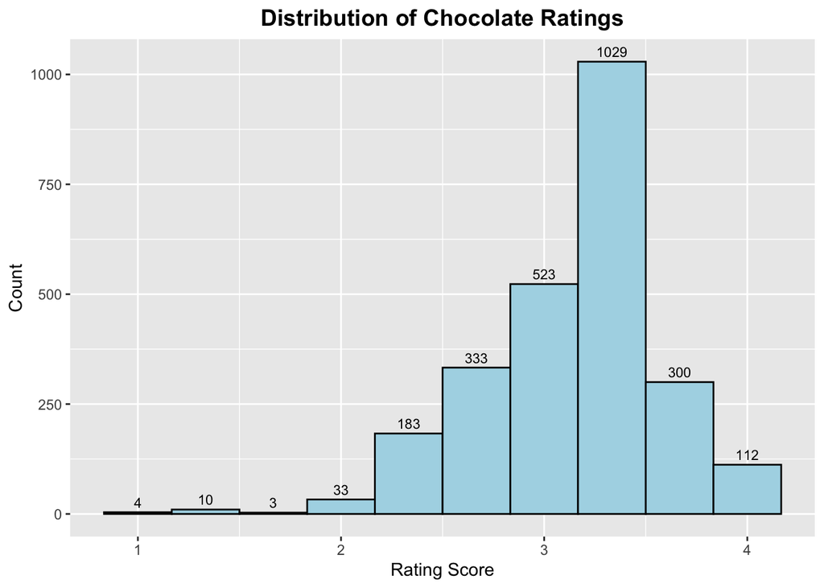

```r
library(dplyr)
library(ggplot2)

# Histogram of rating scores
chocolate %>%
  ggplot(aes(x = rating)) +
  geom_histogram(bins = 10, fill = "lightblue", color = "black") +
  stat_bin(bins = 10, geom = "text", aes(label = after_stat(count)), vjust = -0.5, size = 3, color = "black") +
  labs(title = "Distribution of Chocolate Ratings",
       x = "Rating Score",
       y = "Count") +
  theme(plot.title = element_text(size = 14, face = "bold", color = "black", hjust = 0.5),
        axis.text.x = element_text(angle = 0, hjust = 0.5))
```

As you increase the number of bins, you increase the number of bars, and thus shorten the range of ratings that each bar represents. Smaller bins gives you a more detailed picture of the data, but can lead to gaps in the histogram for ranges of ratings that don’t have any observations. Once you surpassed 10 bins into 15, the histogram started to generate gaps. I chose 10 bins, but would also be okay doing 15. Anything over that would be unnecessary.

**Question 2**

```r
# Reviews from each country of bean origin
reviews_by_country <- chocolate %>%
  group_by(country_of_bean_origin) %>%
  summarise(review_count = n()) %>%
  arrange(desc(review_count))

# Display data frame
reviews_by_country
```

```
## # A tibble: 62 × 2
##    country_of_bean_origin review_count
##    <chr>                         <int>
##  1 Venezuela                       253
##  2 Peru                            244
##  3 Dominican Republic              226
##  4 Ecuador                         219
##  5 Madagascar                      177
##  6 Blend                           156
##  7 Nicaragua                       100
##  8 Bolivia                          80
##  9 Colombia                         79
## 10 Tanzania                         79
## # ℹ 52 more rows
```

**Question 3**

```r
# Average rating of scores from reviews of chocolate bars from Ecuador
avg_ecuador_rating <- mean(chocolate$rating[chocolate$country_of_bean_origin == "Ecuador"], na.rm = TRUE)

# Total number of reviews for chocolate bars from Ecuador
num_ecuador_reviews <- sum(chocolate$country_of_bean_origin == "Ecuador", na.rm = TRUE)

# Standard deviation of ratings for chocolate bars from Ecuador
sd_ecuador_rating <- sd(chocolate$rating[chocolate$country_of_bean_origin == "Ecuador"], na.rm = TRUE)

# Data frame with the results
ecuador_stats <- tibble(
  mean = avg_ecuador_rating,
  sd = sd_ecuador_rating,
  total = num_ecuador_reviews,
)

# Display table
ecuador_stats
```

```
## # A tibble: 1 × 3
##    mean    sd total
##   <dbl> <dbl> <int>
## 1  3.16 0.512   219
```

**Question 4**

```r
# Extract company with highest average rating for chocolate bars made with beans from Ecuador
highest_rated_company_ecuadorbeans <- chocolate %>%
  filter(country_of_bean_origin == "Ecuador") %>%
  group_by(company_location) %>%
  summarise(avg_rating = mean(rating, na.rm = TRUE)) %>%
  arrange(desc(avg_rating)) %>%
  slice(1)

colnames(highest_rated_company_ecuadorbeans) <- c("Company Location", "Average Rating")

# Display the result
highest_rated_company_ecuadorbeans
```

```
## # A tibble: 1 × 2
##   `Company Location` `Average Rating`
##   <chr>                         <dbl>
## 1 Australia                      3.81
```

**Question 5**

```r
# Highest rated countries of bean origin based on average rating
highest_rated_country_of_bean_origin <- chocolate %>%
  group_by(country_of_bean_origin) %>%
  summarise(avg_rating = mean(rating, na.rm = TRUE)) %>%
  arrange(desc(avg_rating))

colnames(highest_rated_country_of_bean_origin) <- c("Country of Bean Origin", "Average Rating")

# Display the top 3 results
head(highest_rated_country_of_bean_origin, 3)
```

```
## # A tibble: 3 × 2
##   `Country of Bean Origin` `Average Rating`
##   <chr>                               <dbl>
## 1 Tobago                               3.62
## 2 China                                3.5
## 3 Sao Tome & Principe                  3.5
```

**Question 6**

```r
# Highest rated countries of bean origin with at least 10 reviews
new_highest_rated_country_of_bean_origin <- chocolate %>%
  group_by(country_of_bean_origin) %>%
  filter(n() >= 10) %>%
  summarise(avg_rating = mean(rating, na.rm = TRUE)) %>%
  arrange(desc(avg_rating))

colnames(new_highest_rated_country_of_bean_origin) <- c("Country of Bean Origin", "Average Rating")

# Display the top 3 results with at least 10 reviews
head(new_highest_rated_country_of_bean_origin, 3)
```

```
## # A tibble: 3 × 2
##   `Country of Bean Origin` `Average Rating`
##   <chr>                               <dbl>
## 1 Solomon Islands                      3.45
## 2 Congo                                3.32
## 3 Cuba                                 3.29
```

**Question 7**

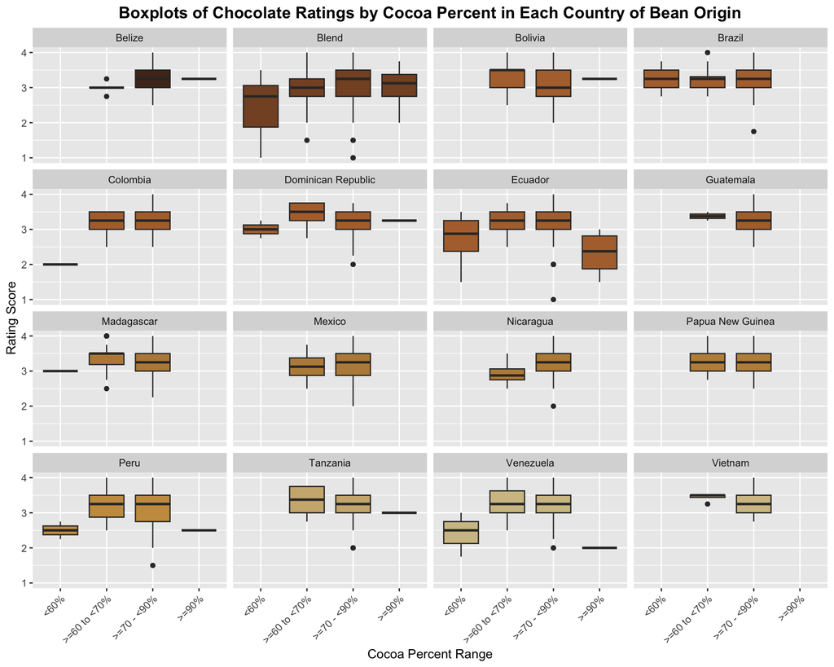

```r
library(lubridate)
library(paletteer)

# Create subset of countries of bean origin with at least 50 reviews
subset_atleast_50_reviews <- chocolate %>%
  group_by(country_of_bean_origin) %>%
  filter(n() >= 50) %>%
  ungroup()

# Create a new variable that categorizes cocoa percent into ranges
subset_atleast_50_reviews <- subset_atleast_50_reviews %>%
  mutate(percent_chocolate = case_when(
    cocoa_percent < 60 ~ "<60%",
    cocoa_percent >= 60 & cocoa_percent < 70 ~ ">=60 to <70%",
    cocoa_percent >= 70 & cocoa_percent < 90 ~ ">=70 - <90%",
    cocoa_percent >= 90 ~ ">=90%"
  ))

# Re-order factor levels for percent_chocolate starting with the lowest percentage group first using fct_relevel from the forcats package
subset_atleast_50_reviews <- subset_atleast_50_reviews %>%
  mutate(percent_chocolate = fct_relevel(percent_chocolate, "<60%", ">=60 to <70%", ">=70 - <90%", ">=90%"))

# For each country, make a set of four side-by-side boxplots plotting the groups on the x-axis and the rating on the y-axis; facet the boxplots by country of bean origin
boxplots_choc_ratings <- subset_atleast_50_reviews %>%
  ggplot(aes(x = percent_chocolate, y = rating, fill = country_of_bean_origin)) +
  geom_boxplot() +
  facet_wrap(~ country_of_bean_origin) +
  scale_fill_manual(values = paletteer_d("beyonce::X117")) +
  labs(title = "Boxplots of Chocolate Ratings by Cocoa Percent in Each Country of Bean Origin",
       x = "Cocoa Percent Range",
       y = "Rating Score") +
  theme(plot.title = element_text(size = 14, face = "bold", color = "black", hjust = 0.5),
        axis.text.x = element_text(angle = 45, hjust = 1),
        legend.position = "none")

# Display the boxplots
boxplots_choc_ratings
```

```r
# Look at table of average ratings by cocoa percent range overall for comparison
subset_atleast_50_reviews %>%
  group_by(percent_chocolate) %>%
  summarise(avg_rating = mean(rating, na.rm = TRUE))
```

```
## # A tibble: 4 × 2
##   percent_chocolate avg_rating
##   <fct>                  <dbl>
## 1 <60%                    2.66
## 2 >=60 to <70%            3.25
## 3 >=70 - <90%             3.22
## 4 >=90%                   2.75
```

On average, chocolate with 60-90% cocoa percent tends to receive higher ratings, with chocolate with >=60 to <70% cocoa percent receiving the highest average rating overall by a small margin. Each country’s individual boxplots show a very similar trend, with Brazil being the only one that has high average ratings for chocolate with less than 60% cocoa percent as well.

## Part 2: Join Two Datasets Together

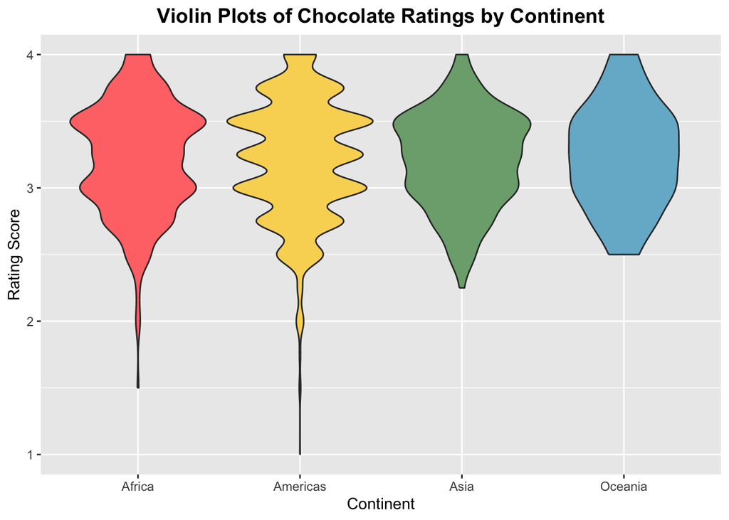

```r
library(gapminder)

# Load in the gapminder dataset
gapminder_data <- gapminder::gapminder

# Add continent column to chocolate dataset based on gapminder dataset
chocolate_w_continent <- chocolate %>%
  left_join(gapminder_data %>%
              select(country, continent) %>%
              distinct(), by = c("country_of_bean_origin" = "country"))

# Remove countries of bean origin that have less than 10 reviews and remove blends from the dataset
chocolate_w_continent <- chocolate_w_continent %>%
  group_by(country_of_bean_origin) %>%
  filter(n() >= 10) %>%
  filter(!(country_of_bean_origin == "Blend")) %>%
  ungroup()

# Identify which countries of bean origin have NA in the continent column
NA_continent <- chocolate_w_continent %>%
  filter(is.na(continent)) %>%
  distinct(country_of_bean_origin)

# replace NA in continent column with correct continent manually
chocolate_w_continent <- chocolate_w_continent %>%
  mutate(continent = case_when(
    country_of_bean_origin == "Fiji" ~ "Oceania",
    country_of_bean_origin == "Papua New Guinea" ~ "Oceania",
    country_of_bean_origin == "Sao Tome" ~ "Africa",
    country_of_bean_origin == "Vanuatu" ~ "Oceania",
    country_of_bean_origin == "Trinidad" ~ "Americas",
    country_of_bean_origin == "Belize" ~ "Americas",
    country_of_bean_origin == "Grenada" ~ "Americas",
    country_of_bean_origin == "Congo" ~ "Africa",
    country_of_bean_origin == "Solomon Islands" ~ "Oceania",
    country_of_bean_origin == "St. Lucia" ~ "Americas",
    country_of_bean_origin == "U.S.A." ~ "Americas",
    TRUE ~ continent
  ))

# Make violin plots with ratings on the y-axis and continent on the x-axis
choc_violin_plot <- chocolate_w_continent %>%
  ggplot(aes(x = continent, y = rating, fill = continent)) +
  geom_violin() +
  scale_fill_manual(values = paletteer_d("ltc::fernande")) +
  labs(title = "Violin Plots of Chocolate Ratings by Continent",
       x = "Continent",
       y = "Rating Score") +
  theme(plot.title = element_text(size = 14, face = "bold", color = "black", hjust = 0.5),
        axis.text.x = element_text(angle = 0, hjust = 0.5),
        legend.position = "none")

# Display the violin plot
choc_violin_plot
```

## Part 3: Convert Wide Data into Long Data

```r
# Creating new binary columns for individual ingredients
chocolate_ingredients <- chocolate %>%
  mutate(beans = case_when(ingredients %>% str_detect("B") ~ 1, TRUE ~ 0)) %>%
  mutate(sugar = case_when(ingredients %>% str_detect("S,|S$") ~ 1, TRUE ~ 0)) %>%
  mutate(cocoa_butter = case_when(ingredients %>% str_detect("C")  ~ 1, TRUE ~0)) %>%
  mutate(vanilla = case_when(ingredients %>% str_detect("V")  ~ 1, TRUE ~0)) %>%
  mutate(letchin = case_when(ingredients %>% str_detect("L")  ~ 1, TRUE ~0)) %>%
  mutate(salt = case_when(ingredients %>% str_detect("Sa")  ~ 1, TRUE ~0))

# Creating new binary columns for most memorable characteristics
chocolate_ingredients_char <- chocolate_ingredients %>%
  mutate(char_cocoa = case_when(most_memorable_characteristics %>% str_detect("cocoa") ~ 1, TRUE ~ 0)) %>%
  mutate(char_sweet = case_when(most_memorable_characteristics %>% str_detect("sweet") ~ 1, TRUE ~ 0)) %>%
  mutate(char_nutty = case_when(most_memorable_characteristics %>% str_detect("nutty") ~ 1, TRUE ~ 0)) %>%
  mutate(char_creamy = case_when(most_memorable_characteristics %>% str_detect("creamy") ~ 1, TRUE ~ 0)) %>%
  mutate(char_roasty = case_when(most_memorable_characteristics %>% str_detect("roasty") ~ 1, TRUE ~ 0)) %>%
  mutate(char_earthy = case_when(most_memorable_characteristics %>% str_detect("earthy") ~ 1, TRUE ~ 0))

# For each year calculate the mean value in each new column previously created across all reviews for that year
choc_ingre_char_by_year <- chocolate_ingredients_char %>%
  group_by(review_date) %>%
  summarise(across(c(beans, sugar, cocoa_butter, vanilla, letchin, salt,
                     char_cocoa, char_sweet, char_nutty, char_creamy, char_roasty, char_earthy),
                   ~ mean(.x,  na.rm = TRUE)))

# Convert wide dataset to long
long_choc_ingre_char_by_year <- choc_ingre_char_by_year %>%
  pivot_longer(cols = c(beans, sugar, cocoa_butter, vanilla, letchin, salt, char_cocoa,
                        char_sweet, char_nutty, char_creamy, char_roasty, char_earthy),
               names_to = "feature",
               values_to = "mean_score")

# Display the long format dataset
long_choc_ingre_char_by_year
```

```
## # A tibble: 192 × 3
##    review_date feature      mean_score
##          <dbl> <chr>             <dbl>
##  1        2006 beans            0.968
##  2        2006 sugar            0.968
##  3        2006 cocoa_butter     0.903
##  4        2006 vanilla          0.694
##  5        2006 letchin          0.694
##  6        2006 salt             0
##  7        2006 char_cocoa       0.210
##  8        2006 char_sweet       0.161
##  9        2006 char_nutty       0.0323
## 10        2006 char_creamy      0.242
## # ℹ 182 more rows
```

## Part 4: Data Visualization

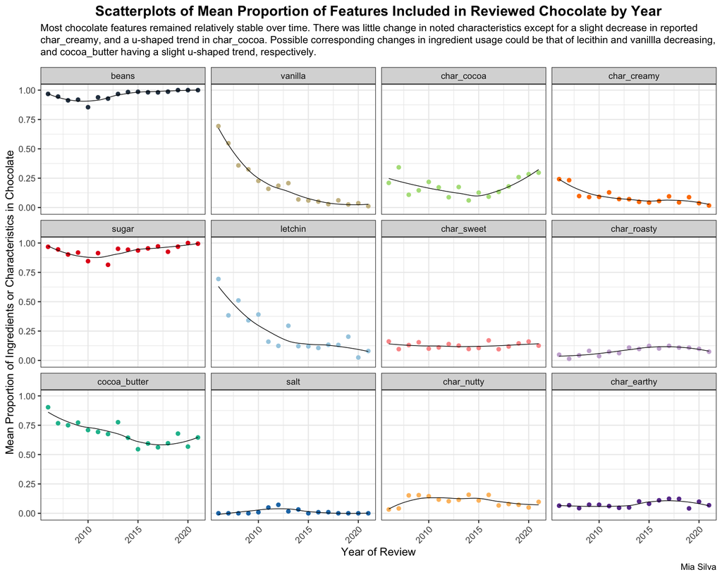

```r
library(ggtext)

# Re-order factor levels so that ingredients are first, followed by characteristics instead of alphabetical order so that they are arranged in a more logical manner in the facets
long_choc_ingre_char_by_year <- long_choc_ingre_char_by_year %>%
  mutate(feature = fct_relevel(feature, "beans", "sugar", "cocoa_butter", "vanilla", "letchin", "salt",
                              "char_cocoa", "char_sweet", "char_nutty", "char_creamy", "char_roasty", "char_earthy"))

# Create scatter plots of mean scores of chocolate features by year with a linear trend line for each feature
scatterplot_choc_by_year <- long_choc_ingre_char_by_year %>%
  ggplot(aes(x = review_date, y = mean_score)) +
  geom_point(aes(color = feature)) +
  geom_smooth(method = "loess", se = FALSE, color = "black", linewidth = 0.3) +
  labs(title = "Scatterplots of Mean Proportion of Features Included in Reviewed Chocolate by Year",
       subtitle = "Most chocolate features remained relatively stable over time. There was little change in noted characteristics except for a slight decrease in reported char_creamy, and a u-shaped trend in char_cocoa. Possible corresponding changes in ingredient usage could be that of lecithin and vanillla decreasing, and cocoa_butter having a slight u-shaped trend, respectively.",
       x = "Year of Review",
       y = "Mean Proportion of Ingredients or Characteristics in Chocolate",
       caption = "Mia Silva") +
  facet_wrap(~ feature, ncol = 4, dir = "v") +
  theme_bw() +
  theme(plot.title = element_text(size = 14, face = "bold", color = "black", hjust = 0.5),
        axis.text.x = element_text(angle = 45, hjust = 1),
        plot.subtitle = element_textbox_simple(size = 10, hjust = 0.5, margin = margin(b = 10, unit = "pt")),
        legend.position = "none") +
  scale_colour_manual(values = paletteer_d("tidyquant::tq_light"))

# Display the scatterplots of mean scores of chocolate features by year
scatterplot_choc_by_year
```

NOTE: the mean_score variable is rather ambiguous in this context, as it translates to the mean proportion of reviews that included a certain ingredient or characteristic. Thus, I made the title and y-axis label more descriptive to clarify this. Mean proportion corresponds to mean score.

## Part 5: Make the worst plot you can!

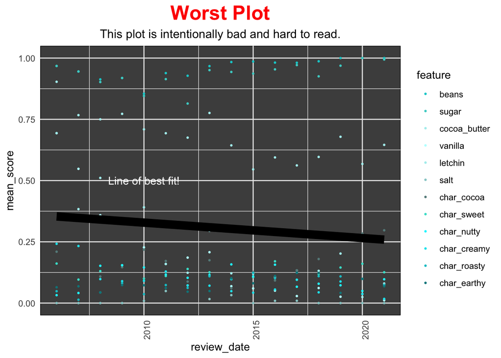

```r
bad_plot <- long_choc_ingre_char_by_year %>%
  ggplot(aes(x = review_date, y = mean_score)) +
  geom_point(aes(color = feature), size = 0.5) +
  annotate("text", x = 2010, y = 0.5, label = "Line of best fit!", color = "white") +
  geom_smooth(method = "lm", se = FALSE, color = "black", linewidth = 4) +
  labs(title = "Worst Plot",
       subtitle = "This plot is intentionally bad and hard to read.") +
  theme_minimal() +
  theme(plot.title = element_text(size = 20, face = "bold", color = "red", hjust = 0.5),
        axis.text.x = element_text(angle = 90, hjust = 1),
        plot.subtitle = element_text(size = 12, hjust = 0.5),
        panel.background = element_rect(fill = "gray30")) +
  scale_colour_manual(values = paletteer_d("NineteenEightyR::youngturqs"))

bad_plot
```

**For this, I used the same data table as the previous part so that the differences are more apparent:**

- I made the plot title large, red, and bold. This makes it quite the eyesore and difficult to look at. In theory this could be okay to draw attention to something in other plots, depending on ones purpose.
- I included all the data on one plot with a legend instead of splitting each chocolate feature up into facets. This makes everything look like a mess of data. However, for a data set with a smaller sample and more distinct trends, it could be useful to see those trends on the same graph.
- I chose a color palette where all the colors are different shades of a similar color. This makes it really hard to differentiate between features plotted, so you can’t easily see individual trends. This could be desirable for those who are trying to maintain a specific aesthetic, and it may be okay when dealing with a smaller amount of features, but would be inadvisable in general.
- I made the plot background dark gray, which is both jarring to look at, especially when maintaining a light theme otherwise. There may be other scenarios where a dark background is useful to create contrast, or is aesthetically preferable, but consistency is key and this particular example simply makes the data harder to look at.
- I added a very thick linear trend line, giving the overall trend of all features, which isn’t at all useful in comparing trends between them. This could possibly be useful when trying to get the overall trend for a smaller selection of features that are more closely related. However, the thickness of line is very unlikely to be helpful in most cases.
- I chose not to give the x and y axis descriptive labels, making it much harder to tell what is being displayed. Generally, I don’t think this would help make a better plot in any scenario as it only helps you save time.
- I rotated the x-axis text 90 degrees, which makes it harder to read. This could be useful if you have a lot of labels that would overlap if they were horizontal, but in this case it is unnecessary. Rotating at a different angle could also help with space and legibility when each label has a longer character length.
- I added an annotation positioned in a less than ideal spot to “describe” the line. It is hard to read due to the grid lines and does not actually inform us of anything useful and is not necessary in this case. However, having an annotation on a graph in general could potentially be useful to label a specific data point of interest (perhaps an outlier), as you can customize the position and size of this annotation.

## Part 6: Make my plot a better plot!

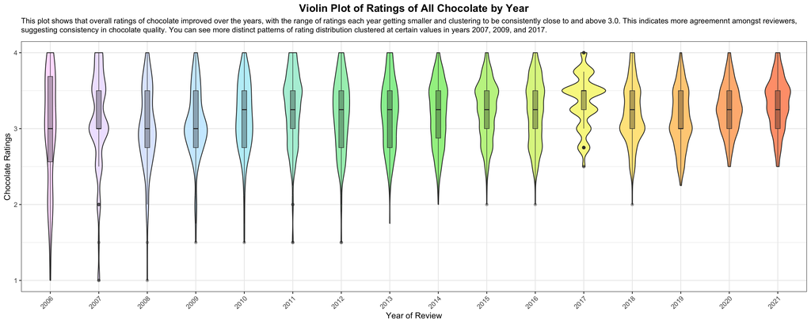

```r
library(paletteer)

chocolate %>%
  ggplot(aes(
        x = as.factor(review_date),
        y = rating,
        fill = review_date
    )) +
  geom_violin(position = position_dodge(0.9),
              linewidth = 0.5) +
  theme_bw() +
  geom_boxplot(width = 0.1,
               position = position_dodge(0.9),
               linewidth = 0.3, fill = "black", alpha = 0.3) +
  labs(title = "Violin Plot of Ratings of All Chocolate by Year",
       subtitle = "This plot shows that overall ratings of chocolate improved over the years, with the range of ratings each year getting smaller and clustering to be consistently close to and above 3.0. This indicates more agreemennt amongst reviewers, suggesting consistency in chocolate quality. You can see more distinct patterns of rating distribution clustered at certain values in years 2007, 2009, and 2017.",
       x = "Year of Review",
       y = "Chocolate Ratings") +
  theme(plot.title = element_text(size = 14, face = "bold", color = "black", hjust = 0.5),
        axis.text.x = element_text(angle = 45, hjust = 1),
        plot.subtitle = element_textbox_simple(size = 10, hjust = 0.5, margin = margin(b = 10, unit = "pt")),
        legend.position = "none") +
  scale_fill_gradientn(colors = c("thistle1", "lightblue1", "lightgreen", "khaki1", "lightsalmon"))
```

- I added a plot title to the figure. This makes it a lot more clear what the plot is showing and is always good practice to do.
- I also added a subtitle noting trends/patterns. This gives an overall description of what the plot shows, specific to the data. It can help the viewer understand what they are looking at.
- I added more descriptive x and y axis labels. This is much more informative and makes it clear what each axis/variable represents.
- I added nicer color customization to violin plots. Aesthetically, this improves the plot, but also having further color differentiation between each year helps to visually interpret the data.
- I also customized the size of the figure in the r chunk setup (which can’t be seen in the code). This helps you see the distribution of each year’s ratings better. In other words, it makes the shape and patterns more defined and distinct. I set fig.width=15 and fig.height=6.
- I added an embedded boxplot to each group so that we can visually see some statistics of interest for each year. You can see the interquartile range and the median rating which can help give more meaning to the sometimes “irregular” looking shapes of the violin plots. You can also see some outliers plotted, giving context as to why a plot may be shaped a certain way and how those outliers influence that shape.
- In addition, I customized the color and size of the box plots. I made them transparent black to make them visually distinct from the violin plots. I also made them smaller in width so that they don’t distort the shape of the violin plots.
- To make it easier to see the plot as a whole, I also made the line widths of violin plots and embedded box plots thinner. When they were thicker it was harder to see the distinct shape of the violin plots.
- To make the violin plots themselves the forefront, I chose a simpler theme that made the background of the plot white. Simplifying the theme makes the figure look less cluttered.
- I also got rid of the legend that was off to the side. Since “review_date” was already displayed as “Year of Review” on the x-axis, it was redundant and simply cluttered the plot.

```r
library(sessioninfo)

options(width = 120)
```